# Dr. Bonoの生命科学データ解析-読書会 @大阪

## 第4章 基本データ解析

### 大阪大学医学部医学科6年/免疫学フロンティアセンター 実験免疫学（坂口研）

### 安水 良明 (twitter : @yyoshiaki)

[figure not shown]

> 坊農秀雅 (2017). 「Dr. Bonoの生命科学データ解析」メディカルサイエンスインターナショナル社

# 今回の発表に用いたjupyter notebookは練習用データと一緒にhttps://github.com/yyoshiaki/drbono.chap4 に置いてあります。

今回のノートブックを開くには、以下の手順。

1. [anaconda](https://www.anaconda.com/download)(python3)をインストール。
2. `$ git clone https://github.com/yyoshiaki/drbono.chap4.git`とターミナルでうち、今回のリポジトリをcloneしてくる。gitがない場合は適宜インストール。
3. `$ jupyter notebook`を立ち上げて、20180414_drbonobon_chap4.ipynbというファイルを実行する。

## 自己紹介

- 安水 良明
- 大阪大学医学部医学科6年
- 免疫学フロンティアセンター 実験免疫学（坂口研）
- Python使ってます。
- 最近[Bioinformatics contest 2018(ITMO大学)](https://bioinf.me/contest)で入賞して喜んでいます。

[figure not shown]

## 4.1配列データ解析

- 配列アラインメントとツール
- マッピング（Suffix Array）
- アセンブル

## 4.2 数値データ解析

- 階層クラスタリング
- PCA

## 4.1配列データ解析

- 配列アラインメントとツール
  - ペアワイズアラインメント
  - ドットプロット
  - 大域的アラインメント（Global Alignment）
  - 局所的アラインメント（Local Alignment）
  - 多重配列アラインメントと系統樹

### ペアワイズアラインメント, ドットプロット

- ２本の配列を比較すること。
- 同じ生物で比べることもあるし、違う生物間で比べることもある。
- 配列解析の出発点。
- それを可視化するのが**ドットプロット**。

だいたいのことは**EMBOSS**で実行できます。

```python
! head seq/L07770.1.fasta
```

```
>L07770.1 Xenopus laevis rhodopsin mRNA, complete cds
GGTAGAACAGCTTCAGTTGGGATCACAGGCTTCTAGGGATCCTTTGGGCAAAAAAGAAACACAGAAGGCA
TTCTTTCTATACAAGAAAGGACTTTATAGAGCTGCTACCATGAACGGAACAGAAGGTCCAAATTTTTATG
TCCCCATGTCCAACAAAACTGGGGTGGTACGAAGCCCATTCGATTACCCTCAGTATTACTTAGCAGAGCC
ATGGCAATATTCAGCACTGGCTGCTTACATGTTCCTGCTCATCCTGCTTGGGTTACCAATCAACTTCATG
ACCTTGTTTGTTACCATCCAGCACAAGAAACTCAGAACACCCCTAAACTACATCCTGCTGAACCTGGTAT
TTGCCAATCACTTCATGGTCCTGTGTGGGTTCACGGTGACAATGTACACCTCAATGCACGGCTACTTCAT
CTTTGGCCAAACTGGTTGCTACATTGAAGGCTTCTTTGCTACACTTGGTGGTGAAGTGGCCCTCTGGTCA
CTGGTAGTATTGGCCGTTGAAAGATATATGGTGGTCTGCAAGCCCATGGCCAACTTCCGATTCGGGGAGA
ACCATGCTATTATGGGTGTAGCCTTCACATGGATCATGGCTTTGTCTTGTGCTGCTCCTCCTCTCTTCGG
```

```python
! head seq/U23808.2.fasta
```

```
>U23808.2 Xenopus laevis rhodopsin gene, complete cds
GGATCCATGTTAGTAGCCTTCAAATCGAGTTTAGTCTAATTTGAATCAAATTCGATAAGAGTTTTCAAGT
CAGCAAAAATTGTACGAGTTTTAGATGTCCAATTTTTTTTTCTATAAGTAATTTAGAGTATATTCGAATT
TAATCGAGTTTAAAAAAATTCACATTAATTCCAAATTCGACCTTTAATCAATGTGCCTCCCAGGATGAGT
GCCAGACTATGAACTCCTCCAACCTATTTATTCATCAACCAGATTTGACAGTGGGAGACCTAAGAATCCA
GTGATTGAATGAGTTTAATGCATGAAAAGGTTGGCTTGGTTATTTGCAGCACAGAGAGAAACCAATAAGG
AGAAAGTAGAGTTGAGGTGGGACATTCATGAATACTCACCTAAAGGACTTTGATTGGGATTCAGCCAATA
ATATCCCATCCACCACATTTACTGAGCTTAGAACATTCTCCAAACATGAGCAGTAAAGGGACAAAGAGTA
ATGGCTTTAAAGGAGAACTAAACCCTAAAACTGAATGTGTAAAAATGTTATATTTTATAGACAGAACTTA
TTGCACCAGCCTAAGTTTCAGCTTGTCAATAGCAGCAATGATCCAGAACTTCAAACTTGTCACAGGGGGT
```

#### アフリカツメガエルのmRNAとgenome配列を比較してみよう。

`$ dottup L07770.1.fasta U23808.2.fasta -wordsize 10 -graph png`

[figure not shown]

### 大域的アラインメント（Global Alignment）と 局所的アラインメント（Local Alignment）

#### 大域的アラインメント（Global Alignment）

大域的アラインメント とは配列中の**全塩基やアミノ酸**を並べるようにする方法。 現在Needleman-Wunch法と呼ばれる方法が広く使われている。

#### 局所的アラインメント（Local Alignment）

大域的アライメントの方法を改良して、部分的な類似性が見つけられるようにしたのが局所的アライメント。局所的アライメントの方法として最もよく用いられているのが Smith-Waterman法。query配列をDBから検索してくるという作業はこの局所的アラインメントのおかげで可能になった。

EMBOSSでの実行例は[大石さんのスライド](https://gitpitch.com/dogrunjp/presentation?p=20171216_drbonobon_4#/0/9)が参考になります。挙動をpythonライブラリの[scikit-bio](http://scikit-bio.org/docs/0.2.0/index.html)で見てみましょう。

```python
from skbio.sequence import DNA
from skbio.alignment import *

s1 = DNA("AGGTGCGTGCCTAAGGTATGCAAGAGATGG")
s2 = DNA("ACGTGCCTAGGTACGCAAG")

# 教育用の関数なので、動作は遅い。下記URLを参照。
# http://scikit-bio.org/docs/0.2.0/alignment.html?highlight=alignment#module-skbio.alignment
r = global_pairwise_align_nucleotide(s1, s2)
# r = local_pairwise_align_nucleotide(s1, s2)
print(r)
```

```
(TabularMSA[DNA]
------------------------------
Stats:
    sequence count: 2
    position count: 30
------------------------------
AGGTGCGTGCCTAAGGTATGCAAGAGATGG
----ACGTGCCTA-GGTACGCAAG------, 8.0, [(0, 29), (0, 18)])
```

#### 局所アラインメントのバリエーション

BLASTとBLATを試してみます。

### BLAST

#### インストール

`$ brew install -v blast`でインストール可能。と記載されていたが、makeblastdb等一部機能がうまく使えなかった。versionの問題か？

`$ conda install blast`だと問題なく行けた。これを機にanacondaを導入しよう！（詳しくは4.2で説明します。）

追記 依存関係に寄るみたいです。brewで入ったという人もいました。お試しください。

#### データベース作成

```python
! head seq/chr22.hg19.fa
```

```
>chr22
NNNNNNNNNNNNNNNNNNNNNNNNNNNNNNNNNNNNNNNNNNNNNNNNNN
NNNNNNNNNNNNNNNNNNNNNNNNNNNNNNNNNNNNNNNNNNNNNNNNNN
NNNNNNNNNNNNNNNNNNNNNNNNNNNNNNNNNNNNNNNNNNNNNNNNNN
NNNNNNNNNNNNNNNNNNNNNNNNNNNNNNNNNNNNNNNNNNNNNNNNNN
NNNNNNNNNNNNNNNNNNNNNNNNNNNNNNNNNNNNNNNNNNNNNNNNNN
NNNNNNNNNNNNNNNNNNNNNNNNNNNNNNNNNNNNNNNNNNNNNNNNNN
NNNNNNNNNNNNNNNNNNNNNNNNNNNNNNNNNNNNNNNNNNNNNNNNNN
NNNNNNNNNNNNNNNNNNNNNNNNNNNNNNNNNNNNNNNNNNNNNNNNNN
NNNNNNNNNNNNNNNNNNNNNNNNNNNNNNNNNNNNNNNNNNNNNNNNNN
```

```python
! makeblastdb -in seq/chr22.hg19.fa -dbtype nucl
```

```
Building a new DB, current time: 04/12/2018 22:18:29
New DB name:   /Users/yasumizuyoshiaki/bioinformatics/bono/seq/chr22.hg19.fa
New DB title:  seq/chr22.hg19.fa
Sequence type: Nucleotide
Deleted existing Nucleotide BLAST database named /Users/yasumizuyoshiaki/bioinformatics/bono/seq/chr22.hg19.fa
Keep MBits: T
Maximum file size: 1000000000B
Adding sequences from FASTA; added 1 sequences in 0.666504 seconds.
```

```python
!ls seq
```

```
L07770.1.fasta    chr22.hg19.fa     chr22.hg19.fa.nin dgcr6.fa
U23808.2.fasta    chr22.hg19.fa.nhr chr22.hg19.fa.nsq
```

#### 検索

今回はDiGeorge症候群に関連するDGCR6のmRNAから配列を取ってきました。

```python
! head seq/dgcr6.fa
```

```
>NM_005675.4 Homo sapiens DiGeorge syndrome critical region gene 6 (DGCR6), mRNA
CGCGAGGCGCGCCGCGATCGGGGACTGTCCTAAGACGGGCGGGGCGCGCTGCGCTAGGGACTGTCATAAA
AGGGGCGGGACGCGCCGCGGTCGGGATGACGTGAGCTGGGGGCGCTCGTCGCTGCAGCCGGCGGCTAGCG
GGCGTCCGCGCCATGGAGCGCTACGCGGGCGCCTTGGAGGAGGTGGCGGACGGTGCCCGGCAGCAGGAGC
GACACTACCAGCTGCTGTCGGCGTTACAGAGCCTGGTGAAGGAGTTGCCCAGCTCATTCCAGCAGCGCTT
GTCCTACACCACGCTGAGCGACCTGGCCCTGGCGCTTCTCGACGGCACCGTGTTCGAAATCGTGCAGGGG
CTACTGGAGATCCAGCACCTCACCGAAAAGAGCCTGTACAACCAGCGCCTGCGCCTACAGAACGAGCATC
GAGTGCTCAGGCAGGCGCTGCGGCAGAAGCACCAGGAAGCCCAGCAGGCCTGCCGGCCCCATAACCTGCC
TGTGCTTCAGGCGGCTCAGCAGCGAGAACTAGAGGCGGTGGAGCACCGGATCCGTGAGGAGCAGCGGGCG
ATGGACCAGAAGATCGTCCTGGAGCTGGACCGGAAGGTGGCTGACCAGCAGAGCACACTGGAGAAGGCGG
```

```python
! blastn -query seq/dgcr6.fa -db seq/chr22.hg19.fa
```

```
BLASTN 2.6.0+


Reference: Zheng Zhang, Scott Schwartz, Lukas Wagner, and Webb
Miller (2000), "A greedy algorithm for aligning DNA sequences", J
Comput Biol 2000; 7(1-2):203-14.



Database: seq/chr22.hg19.fa
           1 sequences; 51,304,566 total letters



Query= NM_005675.4 Homo sapiens DiGeorge syndrome critical region gene 6
(DGCR6), mRNA

Length=1245
                                                                      Score     E
Sequences producing significant alignments:                          (Bits)  Value

  chr22                                                               1020    0.0


> chr22
Length=51304566

 Score = 1020 bits (552),  Expect = 0.0
 Identities = 552/552 (100%), Gaps = 0/552 (0%)
 Strand=Plus/Plus

Query  663       CAGGAGCTGATGCTGCAGATGAACCTGCTGGAACTCATCCGGAAGCTGCAGCAGAGGGGC  722
                 ||||||||||||||||||||||||||||||||||||||||||||||||||||||||||||
Sbjct  18899050  CAGGAGCTGATGCTGCAGATGAACCTGCTGGAACTCATCCGGAAGCTGCAGCAGAGGGGC  18899109

Query  723       TGCTGGGCAGGGAAGGCAGCCCTGGGGCTAGGAGGTCCCTGGCAGTTGCCTGCTGCCCAG  782
                 ||||||||||||||||||||||||||||||||||||||||||||||||||||||||||||
Sbjct  18899110  TGCTGGGCAGGGAAGGCAGCCCTGGGGCTAGGAGGTCCCTGGCAGTTGCCTGCTGCCCAG  18899169

Query  783       TGTGACCAGAAAGGCAGCCCTGTCCCACCATAGCCACAGGCAGCAGAAGTCTGGGCAGAG  842
```

[output cut: 226 more lines]

```
Lambda      K        H
    1.28    0.460    0.850

Effective search space used: 62540234260


  Database: seq/chr22.hg19.fa
    Posted date:  Apr 12, 2018  10:18 PM
  Number of letters in database: 51,304,566
  Number of sequences in database:  1



Matrix: blastn matrix 1 -2
Gap Penalties: Existence: 0, Extension: 2.5
```

#### 扱いやすい形で保存することも出来る

```python
! blastn -query seq/dgcr6.fa -db seq/chr22.hg19.fa -outfmt 7 -out blast.out.txt
```

```python
! head blast.out.txt
```

```
# BLASTN 2.6.0+
# Query: NM_005675.4 Homo sapiens DiGeorge syndrome critical region gene 6 (DGCR6), mRNA
# Database: seq/chr22.hg19.fa
# Fields: query acc.ver, subject acc.ver, % identity, alignment length, mismatches, gap opens, q. start, q. end, s. start, s. end, evalue, bit score
# 10 hits found
NM_005675.4	chr22	100.000	552	0	0	663	1214	18899050	18899601	0.0	1020
NM_005675.4	chr22	98.543	549	8	0	663	1211	20302350	20301802	0.0	970
NM_005675.4	chr22	100.000	262	0	0	1	262	18893736	18893997	6.52e-136	484
NM_005675.4	chr22	91.803	244	18	2	21	262	20307645	20307402	5.37e-92	339
NM_005675.4	chr22	99.405	168	0	1	260	426	18894075	18894242	1.96e-81	303
```

#### BLAST使い方まとめ

1. makeblastdbでDBを作る
2. blast?で検索

| query\DB | 塩基配列 | アミノ酸配列 |
| --- | --- | --- |
| 塩基配列 | blastn, tblastx | blastx |
| アミノ酸配列 | tblastn | blastp |

NCBIのwebサイトやbiopythonを使ってpythonプログラムに組み込むことも可能。

### BLAT

#### インストール

こちらもbrewでうまく行かなかった。`$ conda install -c bioconda blat`でどうぞ。

```python
!blat seq/chr22.hg19.fa seq/dgcr6.fa output.psl
```

```
Loaded 51304566 letters in 1 sequences
Searched 1245 bases in 1 sequences
```

```python
!head output.psl
```

```
psLayout version 3

match	mis- 	rep. 	N's	Q gap	Q gap	T gap	T gap	strand	Q        	Q   	Q    	Q  	T        	T   	T    	T  	block	blockSizes 	qStarts	 tStarts
     	match	match	   	count	bases	count	bases	      	name     	size	start	end	name     	size	start	end	count
---------------------------------------------------------------------------------------------------------------------------------------------------------------
1214	0	0	0	0	0	4	4652	+	NM_005675.4	1245	0	1214	chr22	51304566	18893735	18899601	5	262,161,101,141,549,	0,262,423,524,665,	18893735,18894077,18897684,18898400,18899052,
1120	25	0	0	0	0	5	4652	-	NM_005675.4	1245	66	1211	chr22	51304566	20301801	20307598	6	546,141,101,161,158,38,	34,580,721,822,983,1141,	20301801,20302858,20303641,20307161,20307401,20307560,
```

ラウス肉腫ウイルスが宿主のニワトリから持ち出したと考えられる配列をニワトリゲノムに対して検索する、といったことも可能である。

### 多重配列アラインメントと系統樹

多重配列アラインメント(multiple sequence alignment)は3本以上の配列を並べて、出来る限りギャップをいれないようにして、似たアミノ酸（もしくは塩基）を並べる手法である。アラインメントした結果から分子系統樹を推定し、その結果からアラインメントを更に改良するという作業が行われる。**clustal-omega**や**mafft**が使われる。どちらともwebインターフェースとしても公開されている。

多重配列アラインメントの結果は**Jalview**等のソフトウェアで可視化出来る。詳しくは書籍もしくはtogo tvを参照。

[figure not shown]

## 4.1配列データ解析

- マッピング（Suffix Array） **重要!!!**
  - BWAとBowtie
  - GGRNとGGGenome

### マッピングとは

読んだ配列をヒトゲノムやマウスゲノム等のreferenceに対してどこ由来のリードか検索すること。NGS解析には必要不可欠な作業。

[figure not shown]

> 出典 [EBI-EMBL Train online](https://www.ebi.ac.uk/training/online/course/functional-genomics-ii-common-technologies-and-data-analysis-methods/read-mapping-or)

### BWAとBowtie

BWAとBowtieはNGSから出てきたデータをreference genome配列にマッピングすることに特化したソフトウェア。検索する対象DB（reference genome配列）が予めBurrows Wheeler Transform(BWT)で処理されており、そのため高速に、短い配列に対しても処理を行うことが出来る。

マッピングの流れは基本的に以下。

1. インデックスの作成（referenceに対して一回で良い。）
2. マッピング

#### インストール

condaがおすすめ。個人的にmacでマッピングはしたくない。condaだとsudo権限のないlinuxでも簡単にインストール出来る。

```
$ conda install -c bioconda bowtie
$ conda install -c bioconda bwa
```

#### インデックスの作成

各referenceにつき一度きりで良い。

- bwa `$ bwa index hogenome.fa`
- bowtie `$ bowtie-build hogenome.fa hogenome`

#### マッピング

どちらも入力はfastqファイル（gzで圧縮されたままで大丈夫）、出力はsamファイル。

- bwa `$ bwa -t4 mem hogenome.fa hoge.fastq.gz > hoge.sam`
- bowtie `$ bowtie -q -x hogenome -S hoge.sam -p 4 hoge.fastq.gz`

#### alignerについて諸々

bwaは伝統的にゲノム解析で使われる印象。bowtieは少し古く、bowtie2、更にはhisat、hisat2へと開発が進んでいる。さらに、STARやLASTなど様々な選択肢がある。トランスクリプトーム解析だと最近ではkallistoやsalmonなど、pseudo-alignmentと呼ばれる高速でトランスクリプトームの定量まで行えるソフトウェアが人気。どのワークフローが良いかは日夜議論の対象となっている。

[figure not shown]

> 出典 Mohammad, S. et al. Gaining comprehensive biological insight into the transcriptome by performing a broad-spectrum RNA-seq analysis. doi:10.1038/s41467-017-00050-4

### GGRNAとGGGenome

上述のBWAやBowtieと同様の検索をGoogle検索のように行えるDBCLSのサービス。CRISPR/CasのガイドRNA設計ツールにも応用されている。

```python
! curl http://gggenome.dbcls.jp/hg38/1/AGGTVANNTGACCT.gff
```

```
### ERROR : searcher timed out ###
```

## 4.1配列データ解析

- アセンブル

最近の次世代シーケンサーが長いreadが読めるようになったとはいえ、一本で完全長のDNAなどを読むのはまだ難しい。そこで、次世代シーケンサーによって得られたreadをコンピューター上でつなぎ合わせて再構築する。それがAssemble。

[figure not shown]

> 出典 https://www.slideshare.net/torstenseemann/de-novo-genome-assembly-tseemann-imb-winter-school-2016-brisbane-au-4-july-2016

### assembleについてちょっと詳しく

- genome assemble
  - referenceが無い生物もしくは不十分なreference。
- transcriptome assemble（今回は主にこっちを扱います）
  - 新しいtranscriptomeを拾えるかもしれない。
  - sample特有のtranscriptomeがあるかもしれない。（ex. 癌）
  - TCR再構築

[figure not shown]

> 出典 [TraCeR](http://www.teichlab.org/public/)

### **transcriptome assemble**なら**Trinity**がよく使われる

Trinityはguid referenceなしのアセンブルに用いられる。あまり解析の進んでいない生物にくわえ、ヒトにおけるfusion geneやvirusゲノムの組み込みなどを解析する際にも使える。癌ゲノムに焦点を当てたTrinity Cancer Transcriptome Analysis Toolkit( https://github.com/NCIP/Trinity_CTAT/wiki )なども公開されている。guid referenceが信頼できる場合はStringtieを使うこともできる。

[figure not shown]

## 4.1配列データ解析

- 配列アラインメントとツール
- マッピング（Suffix Array）
- アセンブル

## 4.2 数値データ解析

- **コラム Pythonとは**
- 階層クラスタリング
- PCA

## 4.2 数値データ解析

- **コラム Pythonとは**

[figure not shown]

### Pythonとは

> 文法を極力単純化してコードの可読性を高め、読みやすく、また書きやすくしてプログラマの作業性とコードの信頼性を高めることを重視してデザインされた、汎用の高水準言語である。 wikipedia 「Python」より

フリーかつオープンソースの言語。バイオインフォマティクスだけではなく幅広いコミュニティをもち、web構築やGUI構築、科学演算、機械学習、データベース、ひいてはドローンの操作まで出来る万能言語。

### Rとの比較

様々なところでRとpythonの比較はされている。

- [POSTD : R vs Python：データ解析を比較](https://postd.cc/r-vs-python-head-to-head-data-analysis/)
- [kaggle : Who is the BOSS (Python vs R ) ??](https://www.kaggle.com/stardust0/who-is-the-boss-python-vs-r)

[figure not shown]

統計やバイオインフォマティクス特化ならRで十分。DESeq2など高機能ライブラリもRで用意されている。最新の機械学習やドローンなど、他のこともしたい欲があるならpythonがおすすめ。juliaもじわじわ人気。

### インストール

いろいろやり方がある。そもそもMacならもともとインストールされている。しかし、python3ではなくpython2が入っているので入れ直すのがおすすめ。更に、そのまま入れるより[anaconda](https://www.anaconda.com/download)で一括管理するのがおすすめ。軽量版の[miniconda](https://conda.io/miniconda.html)もある。実行環境はjupyter notebook(まさに今回使っているもの)や、jupyter labがおすすめ。(ana|mini)condaを入れると先程から登場している`$ conda install`が使えるようになる。

## 4.2 数値データ解析

- 階層クラスタリング
- PCA

まとめてpythonでやってみましょう。 データは[Immuno-Navigator](https://sysimm.ifrec.osaka-u.ac.jp/immuno-navigator/)からTregのマイクロアレイデータをダウンロードした。

> Vandenbon, A. et al. Immuno-Navigator, a batch-corrected coexpression database, reveals cell type-specific gene networks in the immune system. Proc. Natl. Acad. Sci. U. S. A. 113, E2393-402 (2016).

```python
import pandas as pd
import matplotlib.pyplot as plt
import seaborn as sns
% matplotlib inline

# immuno-NavigatorからダウンロードしたTregの発現ファイルを読み込み。
df_exp = pd.read_csv('data/expression_3_human.txt', sep='\t')
# Affymetrixのprobe IDの詳細データをダウンロード。これを使って発現テーブルのProbe IDを置き換える。
df_annot = pd.read_csv('data/HG-U133_Plus_2-na36-annot-csv/HG-U133_Plus_2.na36.annot.csv', comment='#')
df_annot = df_annot[['Probe Set ID', 'Gene Symbol']]
df_annot.columns = ['ProbeID', 'GeneSymbol']
df_exp['ProbeID'] = df_exp.index
df_exp = pd.merge(df_exp, df_annot, on='ProbeID', how='inner')
df_exp = df_exp.drop(['ProbeID'], axis=1)
# 一つの遺伝子に複数のProbeが割り当てられている事があるので、平均を取った。
df_exp = df_exp.groupby('GeneSymbol').mean()
df_exp = df_exp[df_exp.index != '---']
```

```python
df_exp
```

| GeneSymbol | GSM266974.CEL | GSM266967.CEL | GSM266970.CEL | GSM266982.CEL | GSM266988.CEL | GSM266972.CEL | GSM266985.CEL | GSM266986.CEL | GSM266975.CEL | GSM266966.CEL | ... | GSM723820.CEL | GSM723824.CEL | GSM723819.CEL | GSM723823.CEL | GSM723825.CEL | GSM723822.CEL | MKLE_133-2_EXP2-TREG-TUBE2_071111_HG-U133_Plus_2.CEL | MKLE_133-2_EXP1-TREG-TUBE14_070511_HG-U133_Plus_2.CEL | MKLE_133-2_EXP1-TREG-P-TUBE18_070511_HG-U133_Plus_2.CEL | MKLE_133-2_EXP2-TREG-P-TUBE6_070511_HG-U133_Plus_2.CEL |
| --- | --- | --- | --- | --- | --- | --- | --- | --- | --- | --- | --- | --- | --- | --- | --- | --- | --- | --- | --- | --- | --- |
| A1BG | 6.329995 | 6.672491 | 6.554513 | 6.370591 | 6.439727 | 6.030856 | 5.976589 | 6.344407 | 6.223625 | 6.300893 | ... | 5.781228 | 6.500306 | 6.572795 | 6.519515 | 6.458826 | 6.598172 | 6.231950 | 6.915423 | 6.154872 | 6.427209 |
| A1BG-AS1 | 5.037404 | 5.686309 | 6.483032 | 5.350224 | 5.415077 | 5.731335 | 5.595510 | 5.958698 | 5.565518 | 5.551137 | ... | 4.918857 | 5.826912 | 5.532381 | 5.621202 | 4.893040 | 5.537691 | 5.401727 | 5.964308 | 5.738294 | 5.632629 |
| A1CF | 4.384173 | 4.398225 | 4.504269 | 4.487556 | 4.027412 | 4.217721 | 3.970703 | 4.053616 | 3.863796 | 4.280985 | ... | 4.041906 | 4.025384 | 3.958178 | 4.084334 | 4.220860 | 4.138160 | 4.321285 | 4.304278 | 4.133247 | 4.441416 |
| A2M | 5.257580 | 5.592144 | 5.431512 | 5.122258 | 4.889085 | 5.122039 | 5.090914 | 4.710800 | 5.149762 | 5.052591 | ... | 5.051330 | 5.554665 | 5.037134 | 5.237206 | 5.497572 | 5.357655 | 5.624329 | 5.253649 | 4.745921 | 5.510778 |
| A2M-AS1 | 6.906687 | 5.845524 | 4.045360 | 5.894904 | 6.369392 | 6.136523 | 7.209754 | 6.270830 | 7.231036 | 6.375537 | ... | 6.507730 | 5.662840 | 6.469428 | 6.107442 | 6.191663 | 6.255368 | 7.022739 | 6.088032 | 5.814550 | 5.900342 |
| A2ML1 | 4.218624 | 4.148094 | 4.327877 | 4.155352 | 4.042741 | 4.051983 | 3.834966 | 4.365218 | 3.862751 | 3.912596 | ... | 4.226010 | 4.128961 | 4.134998 | 4.138744 | 3.924122 | 4.110336 | 4.417305 | 4.147809 | 4.196089 | 4.134112 |
| A2MP1 | 5.258512 | 5.276884 | 3.778824 | 4.896070 | 4.408941 | 4.567173 | 5.295994 | 4.623203 | 4.594767 | 4.674247 | ... | 4.080358 | 4.798134 | 4.171829 | 4.583593 | 4.774224 | 5.165135 | 4.243110 | 4.558537 | 4.952115 | 5.188502 |
| A4GALT | 6.321879 | 5.804474 | 7.195217 | 6.363988 | 6.128443 | 5.523223 | 6.045786 | 6.558648 | 6.094470 | 6.182731 | ... | 5.794614 | 5.987141 | 6.391888 | 6.051665 | 5.976650 | 5.923692 | 5.933604 | 6.429013 | 6.273170 | 6.567489 |
| A4GNT | 4.333680 | 4.474698 | 4.498369 | 4.754718 | 4.213597 | 4.231558 | 4.332090 | 4.182145 | 4.062237 | 4.208773 | ... | 4.306044 | 4.497004 | 4.618224 | 4.693414 | 4.259028 | 4.520218 | 4.237504 | 4.450787 | 4.334868 | 4.539352 |
| AA06 | 5.393698 | 4.665403 | 4.380906 | 4.930437 | 4.771812 | 4.538719 | 4.848835 | 4.383819 | 5.036763 | 4.450124 | ... | 4.788990 | 4.940413 | 4.638221 | 5.078762 | 4.961179 | 5.140533 | 4.580044 | 5.145684 | 4.442799 | 4.528140 |
| AAAS | 7.484228 | 7.285323 | 7.393733 | 7.372531 | 6.956579 | 7.434012 | 7.355164 | 6.789198 | 7.119065 | 7.328291 | ... | 6.957142 | 7.488046 | 7.428081 | 7.781621 | 7.334754 | 7.758605 | 6.609913 | 7.128531 | 7.486500 | 7.323181 |
| AACS | 6.378566 | 6.970323 | 6.365766 | 6.529469 | 6.626753 | 6.575329 | 6.558108 | 6.205369 | 7.171728 | 6.582380 | ... | 6.352892 | 6.286587 | 6.504212 | 6.301055 | 6.306702 | 6.624690 | 6.651286 | 7.232763 | 6.190090 | 6.156982 |
| AACSP1 | 3.145278 | 2.975717 | 3.096689 | 3.062645 | 3.085016 | 2.691928 | 2.689060 | 3.336866 | 3.089322 | 2.992623 | ... | 3.100575 | 2.965334 | 3.071555 | 3.131415 | 2.963740 | 3.091258 | 3.242600 | 2.965728 | 2.923044 | 3.401935 |
| AADAC | 4.846279 | 4.156425 | 5.179911 | 4.457879 | 4.481283 | 4.275923 | 4.432578 | 4.243737 | 4.543590 | 4.292354 | ... | 4.475644 | 4.397545 | 4.486347 | 4.436835 | 4.111668 | 4.320535 | 4.911669 | 4.326585 | 4.451919 | 4.563897 |
| AADACL2 | 3.121081 | 3.474939 | 3.579743 | 3.455728 | 3.152071 | 2.925857 | 2.969151 | 3.197674 | 3.480939 | 3.486558 | ... | 3.081818 | 3.381752 | 3.348910 | 2.801880 | 3.241722 | 3.625903 | 3.113075 | 3.149511 | 3.248608 | 3.013602 |
| AADACP1 | 3.299814 | 3.214657 | 3.278485 | 3.546459 | 3.255058 | 3.525315 | 3.334051 | 3.311696 | 3.625368 | 2.793833 | ... | 3.368335 | 3.706438 | 3.073400 | 3.537613 | 3.221581 | 3.570733 | 3.611234 | 3.050288 | 3.214717 | 3.262152 |
| AADAT | 3.866535 | 4.000587 | 3.863209 | 3.769423 | 3.934697 | 3.566442 | 3.662077 | 3.957041 | 3.925848 | 3.564020 | ... | 3.710834 | 4.018663 | 3.736145 | 3.816661 | 3.617059 | 3.725673 | 4.331902 | 3.899052 | 3.567507 | 3.981494 |
| AAED1 | 7.770825 | 7.098003 | 7.443736 | 6.741960 | 8.518507 | 7.632394 | 8.180012 | 8.054782 | 8.475554 | 7.033080 | ... | 8.330915 | 7.526159 | 7.813668 | 7.613171 | 7.697455 | 7.618173 | 8.008320 | 7.960115 | 7.769471 | 7.836551 |
| AAGAB | 7.098844 | 7.436299 | 7.064280 | 7.383824 | 7.254084 | 7.344425 | 7.308551 | 7.037541 | 7.157243 | 7.088123 | ... | 7.244505 | 7.277905 | 6.518174 | 7.140176 | 6.974104 | 6.849210 | 7.098186 | 6.992624 | 7.332086 | 7.595613 |
| AAK1 | 6.981258 | 6.767286 | 6.618398 | 6.758833 | 6.857997 | 6.984558 | 6.925797 | 6.993195 | 6.841952 | 6.822264 | ... | 7.071926 | 6.846925 | 6.756679 | 7.090422 | 6.897952 | 6.890690 | 6.858001 | 6.902427 | 6.668177 | 6.457301 |
| AAMDC | 5.160006 | 5.324996 | 5.159385 | 5.398079 | 5.174976 | 5.379032 | 5.541379 | 5.431284 | 5.056683 | 5.262009 | ... | 5.531084 | 5.164038 | 5.436543 | 5.210015 | 5.320398 | 5.316070 | 5.211888 | 5.586485 | 5.257232 | 5.245482 |
| AAMP | 7.166707 | 7.829989 | 6.709885 | 6.956228 | 7.471870 | 8.035248 | 7.469542 | 7.332768 | 7.126895 | 7.593800 | ... | 7.206061 | 7.583037 | 7.930606 | 7.857851 | 7.872428 | 7.845199 | 7.161119 | 7.073605 | 7.812235 | 7.758489 |
| AANAT | 3.694477 | 3.484826 | 4.684714 | 3.801925 | 3.689042 | 3.716612 | 3.413324 | 3.718113 | 3.376590 | 3.517447 | ... | 3.706694 | 3.890034 | 3.637831 | 3.620472 | 3.757300 | 4.024139 | 3.371585 | 4.069667 | 3.429284 | 3.456324 |
| AAR2 | 7.877142 | 8.085598 | 7.132338 | 7.930943 | 8.252844 | 7.944194 | 7.854837 | 8.126661 | 8.300647 | 7.639179 | ... | 8.015395 | 8.163611 | 8.388253 | 8.274179 | 8.178604 | 8.178095 | 7.631466 | 7.830055 | 8.281054 | 8.187867 |
| AARS | 8.144657 | 8.753102 | 7.837781 | 7.968016 | 8.193309 | 9.092173 | 8.951710 | 8.091970 | 8.058308 | 9.020546 | ... | 8.125359 | 8.424393 | 8.630149 | 8.817591 | 8.887776 | 8.996524 | 7.736918 | 8.288400 | 8.981580 | 8.912190 |
| AARS2 | 6.579071 | 6.678795 | 6.255364 | 6.537113 | 6.850929 | 6.786886 | 7.166372 | 6.838984 | 6.682881 | 6.682269 | ... | 6.617070 | 6.556515 | 6.934701 | 6.767751 | 6.694380 | 6.857485 | 6.256266 | 6.719111 | 7.103893 | 6.790279 |
| AARSD1 /// PTGES3L-AARSD1 | 6.489105 | 7.319580 | 5.668359 | 6.370102 | 6.896480 | 6.707557 | 6.738000 | 6.871708 | 6.689252 | 6.375201 | ... | 6.073023 | 6.971701 | 6.883990 | 7.050118 | 6.582501 | 6.501194 | 5.966756 | 6.372048 | 7.114629 | 6.453428 |
| AASDH | 7.074000 | 8.195313 | 7.210623 | 7.514958 | 7.528762 | 8.248522 | 7.957446 | 7.505874 | 7.280934 | 7.976176 | ... | 7.762211 | 7.152091 | 7.999862 | 7.408004 | 7.462255 | 7.795535 | 7.340061 | 7.693434 | 7.468181 | 7.374443 |
| AASDHPPT | 7.321247 | 7.100702 | 7.404780 | 7.517359 | 7.610962 | 7.826139 | 7.162326 | 7.427644 | 7.114044 | 7.539108 | ... | 7.344945 | 7.355283 | 6.966186 | 7.273707 | 7.468971 | 7.346118 | 7.337866 | 7.249796 | 7.136639 | 7.419338 |
| AASS | 4.745798 | 4.626478 | 5.116449 | 4.634705 | 4.655642 | 4.473566 | 4.273255 | 4.689584 | 4.858475 | 5.069104 | ... | 4.697543 | 4.972510 | 4.533027 | 4.606036 | 4.673496 | 4.234631 | 5.136650 | 4.465306 | 4.709777 | 5.057968 |
| ... | ... | ... | ... | ... | ... | ... | ... | ... | ... | ... | ... | ... | ... | ... | ... | ... | ... | ... | ... | ... | ... |
| ZSCAN25 | 6.965716 | 7.343121 | 6.776739 | 7.431333 | 7.158724 | 7.069241 | 7.175228 | 7.062324 | 7.067914 | 7.177454 | ... | 7.438494 | 7.309628 | 7.518539 | 7.111170 | 7.274723 | 7.381359 | 6.800567 | 7.013460 | 6.919259 | 6.967833 |
| ZSCAN26 | 6.472607 | 7.525173 | 6.038698 | 6.182118 | 6.456805 | 7.507058 | 7.577202 | 6.629014 | 6.148266 | 7.364820 | ... | 7.551551 | 6.939673 | 7.012030 | 6.865640 | 6.978210 | 6.712314 | 5.842205 | 6.163694 | 7.169735 | 6.785658 |
| ZSCAN29 | 6.822445 | 7.991624 | 7.014349 | 7.484403 | 7.293331 | 8.098088 | 8.206188 | 7.358728 | 7.321688 | 8.204116 | ... | 8.102251 | 7.829694 | 8.051798 | 7.815997 | 7.089490 | 7.957736 | 7.418007 | 7.325251 | 7.897328 | 7.853105 |
| ZSCAN30 | 5.891297 | 6.100541 | 5.588563 | 5.557731 | 5.806909 | 5.955336 | 5.934812 | 5.557202 | 5.685127 | 5.975555 | ... | 5.802787 | 5.987463 | 5.669433 | 5.852736 | 5.841063 | 5.578973 | 5.848648 | 5.576084 | 5.618770 | 5.763638 |
| ZSCAN31 | 4.969071 | 3.803487 | 4.153126 | 4.184705 | 4.563488 | 3.349163 | 3.791677 | 3.647429 | 4.056464 | 4.461130 | ... | 5.464177 | 3.594939 | 4.555461 | 4.011858 | 3.505327 | 4.133448 | 3.337982 | 3.845519 | 4.605612 | 3.783439 |
| ZSCAN32 | 6.482495 | 6.891778 | 6.130611 | 6.224822 | 6.673122 | 6.886765 | 6.616539 | 6.275076 | 6.037710 | 6.895340 | ... | 6.599642 | 6.682538 | 6.942645 | 6.744576 | 6.669189 | 6.475831 | 6.125477 | 6.492872 | 6.662209 | 6.854058 |
| ZSCAN4 | 3.149061 | 3.590883 | 3.339891 | 3.229534 | 3.444897 | 3.250199 | 3.297852 | 3.555481 | 3.396513 | 3.111150 | ... | 3.439371 | 3.276863 | 3.150498 | 3.095562 | 3.146420 | 3.578157 | 3.055982 | 3.193255 | 3.346913 | 3.235752 |
| ZSCAN5A | 4.938788 | 4.960243 | 4.743162 | 4.862338 | 4.764949 | 5.115277 | 4.973510 | 4.894480 | 4.696079 | 4.784316 | ... | 4.885687 | 4.972420 | 5.098590 | 4.889080 | 4.389971 | 4.768561 | 4.639562 | 4.910014 | 4.653369 | 4.809885 |
| ZSCAN9 | 6.561056 | 7.315718 | 6.598600 | 7.104977 | 7.060993 | 7.247849 | 7.606776 | 6.724439 | 6.246730 | 7.249823 | ... | 7.654670 | 7.312807 | 7.315430 | 7.192130 | 7.119312 | 7.421506 | 6.304430 | 6.550459 | 7.294009 | 7.534429 |
| ZSWIM1 | 6.377744 | 6.256704 | 6.443409 | 6.174444 | 5.542088 | 6.291561 | 6.006684 | 6.177934 | 6.187452 | 6.052880 | ... | 6.885835 | 6.175371 | 6.398363 | 6.281831 | 6.200171 | 6.027931 | 6.128073 | 6.022472 | 5.786127 | 5.879002 |
| ZSWIM2 | 3.135231 | 3.154574 | 3.104452 | 3.532067 | 3.240295 | 2.849146 | 3.269629 | 3.181506 | 3.253384 | 3.020387 | ... | 3.204598 | 3.328911 | 3.302065 | 3.179092 | 3.315916 | 3.313163 | 3.695217 | 3.248029 | 3.093018 | 3.100363 |
| ZSWIM3 | 5.810809 | 6.445546 | 5.801737 | 5.670764 | 5.252791 | 6.448127 | 5.892647 | 5.692403 | 5.636769 | 6.289205 | ... | 6.485304 | 6.286789 | 6.243936 | 6.487948 | 6.188584 | 5.741934 | 5.646498 | 5.809768 | 6.356532 | 5.606267 |
| ZSWIM4 | 5.123830 | 4.247439 | 4.935015 | 4.177440 | 4.125815 | 4.142566 | 3.823305 | 4.377297 | 4.034792 | 4.005143 | ... | 3.969417 | 4.325007 | 4.270083 | 4.475759 | 4.239169 | 4.543260 | 4.871726 | 4.783760 | 4.427503 | 4.115403 |
| ZSWIM5 | 5.061247 | 4.268369 | 5.620412 | 5.010646 | 5.304072 | 5.250946 | 5.135438 | 5.187186 | 5.385591 | 4.777841 | ... | 5.589952 | 4.984416 | 4.999301 | 4.894395 | 5.267742 | 5.193105 | 4.893966 | 5.111675 | 4.760028 | 4.761519 |
| ZSWIM6 | 7.104259 | 8.302044 | 6.819198 | 7.737233 | 7.638553 | 8.412299 | 8.423985 | 7.671966 | 7.570882 | 8.738596 | ... | 8.115822 | 8.003511 | 7.070686 | 8.012586 | 7.896693 | 7.931935 | 7.710851 | 7.720100 | 8.216624 | 8.419844 |
| ZSWIM7 | 5.762341 | 6.296414 | 5.195159 | 5.876310 | 6.557895 | 6.621798 | 6.645763 | 6.108089 | 6.020111 | 6.707180 | ... | 6.480891 | 5.920207 | 6.236654 | 6.150594 | 5.615262 | 6.349885 | 6.465304 | 6.343185 | 6.583639 | 5.869975 |
| ZSWIM8 | 6.655869 | 6.354241 | 6.745099 | 6.092956 | 6.183647 | 5.979727 | 6.028081 | 6.451701 | 6.280447 | 6.112246 | ... | 6.244308 | 6.375418 | 6.582424 | 6.592328 | 6.024382 | 6.100777 | 6.117906 | 6.923466 | 6.496569 | 6.372735 |
| ZUFSP | 7.815441 | 6.824549 | 6.347263 | 7.799579 | 8.210375 | 6.952307 | 7.272167 | 7.805215 | 7.951880 | 7.314708 | ... | 8.168623 | 7.243567 | 7.181108 | 7.251295 | 7.055141 | 6.923462 | 7.794678 | 7.446957 | 7.075280 | 6.902104 |
| ZW10 | 6.785843 | 7.834948 | 6.418325 | 6.727571 | 7.233974 | 7.746689 | 7.798367 | 6.920381 | 6.789222 | 7.437107 | ... | 6.582008 | 7.115714 | 7.562147 | 7.279648 | 7.565980 | 7.197110 | 7.033704 | 6.921524 | 7.656918 | 7.565217 |
| ZWILCH | 7.201657 | 6.297545 | 6.798789 | 7.659460 | 7.289148 | 7.178505 | 7.198985 | 6.854641 | 7.486535 | 7.487574 | ... | 7.228371 | 6.925207 | 7.324762 | 7.082216 | 6.915969 | 7.206885 | 7.526647 | 7.521560 | 6.728067 | 6.599255 |
| ZWINT | 6.248166 | 7.954764 | 7.121643 | 7.078205 | 6.858055 | 7.994592 | 7.582563 | 6.923124 | 6.798789 | 6.876908 | ... | 7.562404 | 6.694565 | 7.465004 | 7.010036 | 6.962721 | 7.015432 | 8.563703 | 7.789426 | 7.296689 | 7.333868 |
| ZXDA | 6.602988 | 5.820766 | 6.208023 | 6.766386 | 7.130399 | 6.547887 | 6.243968 | 6.936459 | 7.004140 | 6.985058 | ... | 7.669662 | 6.310258 | 6.646783 | 6.102405 | 6.306645 | 6.533250 | 6.135229 | 6.350061 | 6.286034 | 6.294129 |
| ZXDA /// ZXDB | 5.169698 | 4.907419 | 4.954019 | 5.181062 | 5.492337 | 4.575762 | 4.931880 | 5.634828 | 5.371257 | 4.814620 | ... | 5.054535 | 4.769206 | 5.484213 | 4.776155 | 4.945827 | 4.986257 | 4.996734 | 5.559169 | 4.571086 | 4.648404 |
| ZXDB | 5.831605 | 5.634411 | 5.567937 | 5.796505 | 6.442235 | 5.254390 | 5.474351 | 6.268193 | 5.887443 | 5.734685 | ... | 6.098971 | 5.255370 | 6.116957 | 5.470177 | 5.542593 | 5.776629 | 5.674837 | 6.041412 | 5.380701 | 5.062694 |
| ZXDC | 6.331872 | 5.919160 | 5.781993 | 6.413931 | 6.252410 | 6.393202 | 6.203285 | 6.409323 | 6.478785 | 6.346135 | ... | 6.440188 | 6.001538 | 6.354298 | 6.333354 | 6.079599 | 6.031899 | 6.376990 | 6.241490 | 6.193611 | 5.963847 |
| ZYG11A | 5.910114 | 5.272793 | 5.337675 | 5.240433 | 5.099909 | 5.066068 | 4.760521 | 5.002463 | 5.431786 | 4.950386 | ... | 5.669280 | 4.925695 | 5.471463 | 4.913366 | 5.637031 | 5.092262 | 4.605311 | 5.450916 | 5.086130 | 5.653435 |
| ZYG11B | 8.675450 | 8.410204 | 8.054727 | 8.710899 | 8.558867 | 9.090438 | 9.143191 | 8.080272 | 8.936341 | 9.006650 | ... | 8.753219 | 8.374556 | 8.744095 | 8.499122 | 8.263795 | 8.594041 | 8.670517 | 8.597402 | 7.923820 | 7.892749 |
| ZYX | 6.468198 | 6.532613 | 6.003965 | 6.111791 | 6.519835 | 6.744659 | 6.328306 | 7.069401 | 6.805881 | 6.572609 | ... | 6.356087 | 6.640681 | 6.923513 | 6.907630 | 6.808598 | 7.024192 | 6.912290 | 7.288850 | 6.580884 | 6.160194 |
| ZZEF1 | 7.136295 | 6.511970 | 6.227152 | 6.447227 | 7.103101 | 6.457195 | 6.483693 | 6.917548 | 7.162369 | 6.171867 | ... | 6.454512 | 6.744475 | 6.576435 | 6.741442 | 6.697681 | 6.769907 | 6.949340 | 7.129077 | 6.618018 | 6.409453 |
| ZZZ3 | 7.958952 | 8.502548 | 7.146590 | 8.289285 | 8.559358 | 8.613209 | 8.818681 | 8.361559 | 8.665872 | 8.577187 | ... | 8.492928 | 8.622157 | 8.445104 | 8.059314 | 8.574227 | 8.443216 | 8.022772 | 7.951454 | 8.449775 | 8.402241 |

22485 rows × 65 columns

```python
# 変動係数を出してみる
(df_exp.std(axis=1) / df_exp.mean(axis=1)).sort_values(ascending=False).head(10)
```

```
GeneSymbol
EIF1AY    3.306372
IL3       0.716975
IL4       0.687709
IL5       0.604539
KDM5D     0.603147
FASLG     0.534145
USP9Y     0.487174
RPS4Y1    0.480955
IFNG      0.470246
DDX3Y     0.451477
dtype: float64
```

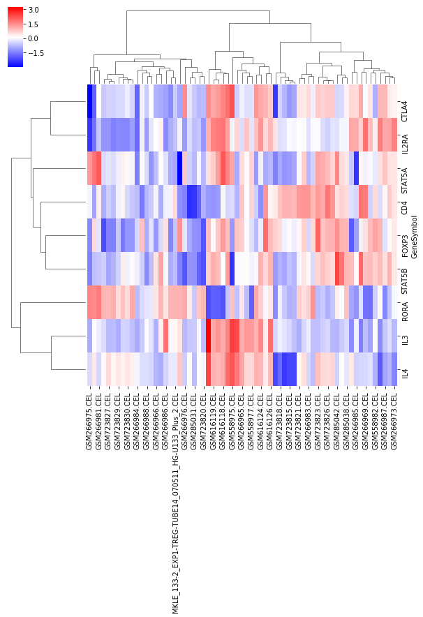

```python
sns.clustermap(df_exp.loc[['FOXP3', 'CTLA4', 'IL2RA', 'STAT5A', 'STAT5B', 'CD4', 'RORA', 'IL3', 'IL4']],
               z_score=0, cmap='bwr', method='ward')
```

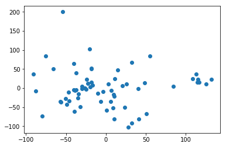

```python
from sklearn.preprocessing import StandardScaler
from sklearn.decomposition import PCA
# from sklearn.manifold import TSNE


# PCAの前に正規化したほうが良いです。
# http://scikit-learn.org/stable/auto_examples/preprocessing/plot_scaling_importance.html

# 正規化
X = StandardScaler().fit_transform(df_exp.T)
# PCA
pca = PCA(n_components=50)
pca.fit(X)
result = pca.transform(X)
# plot
plt.scatter(result[:,0], result[:,1])
# plt.savefig('img/pca.png')
```

```python
# 固有ベクトル(Loadings)を分析
df_comp = pd.DataFrame(pca.components_)
df_comp.columns = df_exp.index
```

```python
df_comp.loc[0].abs().sort_values(ascending=False).head(20)
```

```
GeneSymbol
TMEM41B                      0.016315
OTUB1                        0.016224
OGFR                         0.016120
OPA1                         0.016079
ARHGAP4                      0.016032
ABCA5                        0.016021
DNASE2                       0.015974
SENP6                        0.015971
C7orf55-LUC7L2 /// LUC7L2    0.015959
HIGD2A                       0.015957
EVA1B                        0.015934
MRPL28                       0.015931
CORO1B                       0.015889
GPAA1                        0.015802
TVP23B                       0.015796
NAF1                         0.015763
ACAP1                        0.015735
TSTA3                        0.015664
ICAM3                        0.015663
MAP2K2                       0.015623
Name: 0, dtype: float64
```

```python
df_comp.loc[1].abs().sort_values(ascending=False).head(20)
```

```
GeneSymbol
PIGF                    0.016535
NUDT5                   0.016494
GJA9-MYCBP /// MYCBP    0.016339
PDCD6IP                 0.016294
MSH2                    0.016248
IPP                     0.016052
CYB5B                   0.016014
TPST2                   0.015695
UNG                     0.015691
PRIM1                   0.015672
LDAH                    0.015669
INTS7                   0.015621
HMGN4                   0.015610
CBX1                    0.015608
KRCC1                   0.015592
HSPB11                  0.015587
ZNF75D                  0.015587
HENMT1                  0.015557
DNAJA3                  0.015556
RNF20                   0.015531
Name: 1, dtype: float64
```

```
Text(0.5,0,'PC')
```

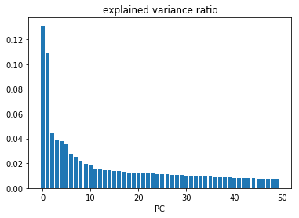

```python
# 寄与率
plt.bar(range(50),pca.explained_variance_ratio_)
plt.title('explained variance ratio')
plt.xlabel('PC')
```

```python
# plotlyで更にわかりやすく
import plotly.offline as offline
import plotly.graph_objs as go
offline.init_notebook_mode()

# Create a trace
trace = go.Scatter(
    x = result[:,0],
    y = result[:,1],
    mode = 'markers',
    text = df_exp.columns,
    marker = dict(
        color = df_exp.loc['FOXP3'],
        size='16',
        colorscale='Viridis',
        showscale=True,
        colorbar = dict(title = 'FOXP3')
    )
)

data = [trace]

layout=dict(title='PCA')
fig=dict(data=[trace], layout=layout)
# はみ出るので次のスライドいきます。
# offline.iplot(fig, filename='PCA')
```

```python
offline.iplot(fig, filename='PCA')
```

[interactive chart not shown]

### 使ったライブラリまとめ

- scikit-learn : Google社製機械学習ライブラリ。PCAのために利用。死角なし。
- pandas : 同じくデータサイエンス3本柱の一つ。データフレームオブジェクトと豊富な機能が利用可能。
- matplotlib : 鉄板可視化ライブラリ。これを知らずにpythonを知っているとは言えない。
- seaborn : クラスターマップに使用。matplotlibをリッチにしてくれる。
- plotly : インタラクティブな可視化が出来るライブラリ。これも熱い。
- scikit-bio : alignmentの例で使用。

#### Pythonの勉強を始めたいと思った方へ

- [udemy 【世界で5万人が受講】実践 Python データサイエンス](https://www.udemy.com/python-jp/) : 17.5hのビデオ講座。私はこれで始めました。有料。
- [rosalind](http://rosalind.info/problems/locations/) : bioinformaticsの練習サイト。少し慣れてきたら。
- その他書籍、オンライン学習等色々あります。

#### 情報収集手段（Pythonに限らないが。）

- [qiita](https://qiita.com/trend) : プログラマのための技術情報共有サービス。
- [kaggle](https://www.kaggle.com) : データサイエンスコンペティションのプラットフォーム。kernelなど、可視化やデータ処理の参考に。
- twitter,blog : バイオインフォマティクス界隈の人や情報界隈の人は割とやっている人が多い。「bounohu blog」「六本木で働くデータサイエンティストのブログ」「驚異のアニヲタ社会復帰への道」「macでインフォマティクス」などなど他分野にわたる。twitterで有名論文公式や有名研究者などをフォローしたり、RSSでまとめてブログをよんだり。
- [google](http://google.co.jp) : 言わずもがな。なんでも調べる。エラーが出たらエラーをコピペ。

# とにかく、いろいろ触ってみるのが大事だと思います。